# Formation-R-perfectionnement

## 12.6 Habillage du graphique

- Il existe des thèmes prédéfinis que l’on peut ajouter à un graphique

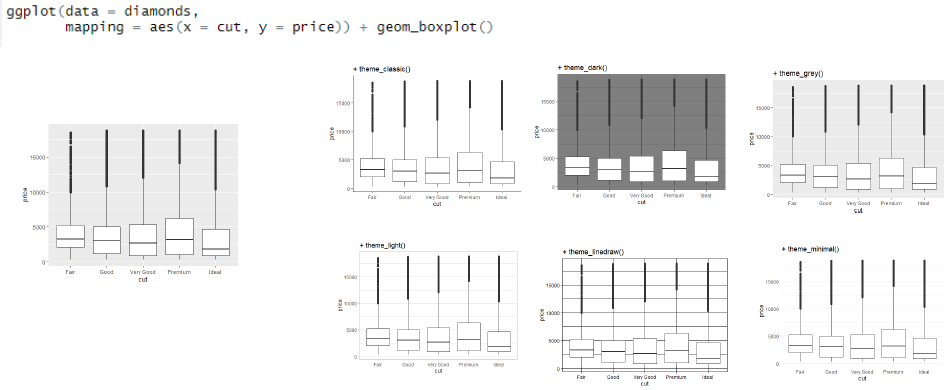

## 12.7 Habillage du graphique

On peut modifier l’ensemble des libellés avec la fonction **labs()**

- *title* = titre du graphique
- *subtitle* = sous-titre
- *x,y* = noms des axes
- *fill, colour, size, alpha* = intitulé de la légende
- *caption* = source de données

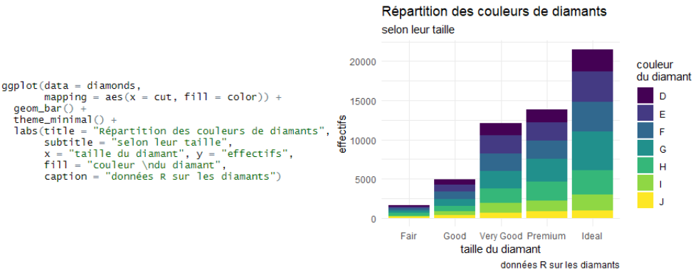

## 12.8 Zoom sur un graphique

Attention à l’argument **limits** de la fonction `scale_x_continuous()` qui enlève les données hors de l’intervalle.  
Selon que celui-ci est ouvert ou fermé, ggplot2 peut supprimer des barres.

=> Pour zoomer sur un graphique, la bonne pratique est d’utiliser la fonction `coord_cartesian()` et son argument **xlim**.

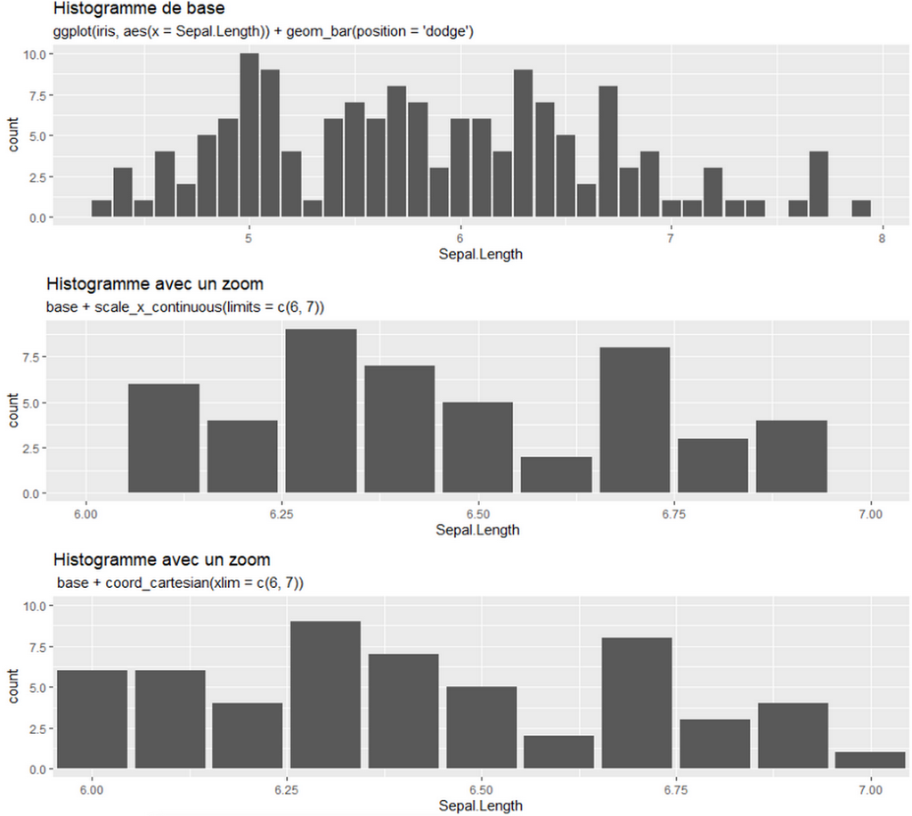

# 13 Sauvegarde du graphique

## 13.1 Sauvegarde du graphique

- La sauvegarde du graphique peut se faire avec le bouton « export » de l’onglet « Plots »

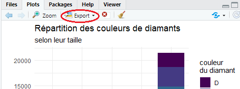

- On peut également sauvegarder un graphique avec la fonction `ggsave()`
  - possibilité d’exporter au format pdf, svg, png, etc. → il suffit de l’indiquer dans l’extension du nom de fichier en sortie
  - par défaut, la fonction exporte le dernier graphique possibilité de choisir la taille et la résolution du graphique exporté

# 14 Pour aller plus loin…

## 14.1 Liens

- Des exemples de graphiques inspirants (à mettre en favoris) https://www.r-graph-gallery.com/
- Le livre de recette de ggplot2 (UN MUST) https://r-graphics.org/
- Un flipbook pour bien comprendre la superposition des éléments d’un graphique. Par exemple https://evamaerey.github.io/ggplot_flipbook/ggplot_flipbook_xaringan.html#1
- Une liste des différentes extensions de ggplot2 https://exts.ggplot2.tidyverse.org/gallery/
- Le package **{esquisse}** pour construire une ébauche de graphique et générer le code => https://dreamrs.shinyapps.io/esquisse/

# 15 Exercices

## 15.1 Exercice 1

**Exercice 1**

À partir des données de la base prenoms :

- Tracer la courbe de l’évolution du nombre de naissances de Camille depuis 2000. Choisir une largeur de ligne de 1 et colorer la courbe en orange. **Attention, la variable correspondant à l’année de naissance doit être numérique.**

*Indication : agréger d’abord les données pour l’ensemble des départements pour obtenir le nombre total d’enfants prénommés «Camille» pour chaque année depuis 2000.*

- Tracer la courbe de l’évolution du nombre de naissances de « Camille » selon le sexe de l’enfant.
- Pour aller plus loin : ajouter au graphique la courbe représentant le total (F+G) et mettre en pointillés les deux autres courbes.

## 15.2 Résultat attendu - exercice 1

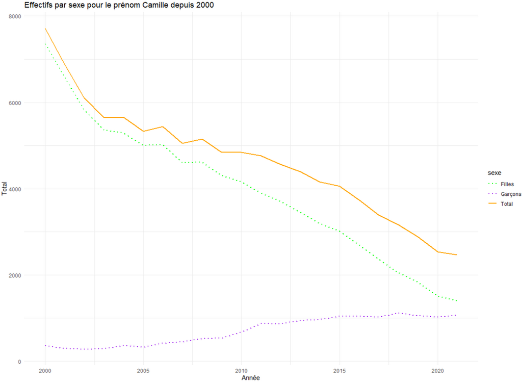

[figure not shown]